# 3.2-DEseq2

Olivia

2023-05-11

# 1 Generate a plot and table of differentially expressed genes

## 1.1 For this assignment you will be taking RNA-seq reads off the sequencer, and determining what genes are expressed higher in treatment group A compared to treatments group B. Why would someone want to do this? This can tell you something about the physiological response to a “treatment”, which generally speaking could be anything from environment, disease, developmental stage, tissue, species…

### 1.1.1 create directory called “programs”

#ran this in terminal olivia@raven:~/gitrepos/olivia-classwork$ pwd /home/olivia/gitrepos/olivia-classwork olivia@raven:~/gitrepos/olivia-classwork$ mkdir programs

### 1.1.2 WGet kallisto

#ran in terminal olivia@raven:~/gitrepos/olivia-classwork$ cd programs olivia@raven:~/gitrepos/olivia-classwork/programs$ wget https://github.com/pachterlab/kallisto/releases/download/v0.46.1/kallisto_linux-v0.46.1.tar.gz #kallisto_linux-v0.46.1.tar.gz’ saved [7274037/7274037] olivia@raven:~/gitrepos/olivia-classwork/programs$ tar -xvzf kallisto_linux-v0.46.1.tar.gz

### 1.1.3 Uncompress the file

#ran in terminal olivia@raven:~/gitrepos/olivia-classwork/programs$ cd kallisto olivia@raven:~/gitrepos/olivia-classwork/programs/kallisto$ ls kallisto license.txt README.md test olivia@raven:~/gitrepos/olivia-classwork/programs/kallisto$ ./kallisto kallisto 0.46.1

Usage: kallisto [arguments] ..

Where can be one of:

```
index         Builds a kallisto index
quant         Runs the quantification algorithm
bus           Generate BUS files for single-cell data
pseudo        Runs the pseudoalignment step
merge         Merges several batch runs
h5dump        Converts HDF5-formatted results to plaintext
inspect       Inspects and gives information about an index
version       Prints version information
cite          Prints citation information
```

# 2 Running Kallisto

## 2.1 download reference genome

```bash
cd data
curl --insecure -O https://gannet.fish.washington.edu/seashell/bu-github/nb-2023/Cgigas/data/rna.fna
```

#### 2.1.0.1 make index file and rename it as cgigas_roslin_rna.index

```bash
/home/shared/kallisto/kallisto \
 index -i \
~/gitrepos/olivia-classwork/data/cgigas_roslin_rna.index \
~/gitrepos/olivia-classwork/data/rna.fna
```

#### 2.1.0.2 download sequence reads

```bash
#ran in terminal
~/gitrepos/olivia-classwork/data
wget --recursive --no-parent --no-directories \
--no-check-certificate \
--accept '*.fastq.gz' \
https://gannet.fish.washington.edu/seashell/bu-github/nb-2023/Cgigas/data/nopp/
```

### 2.1.1 look for all files ending in L001_R1_001.fastq.gz

```bash
find ~/gitrepos/olivia-classwork/assignments/code/*fastq.gz \
| xargs basename -s _L001_R1_001.fastq.gz | xargs -I{} /home/shared/kallisto/kallisto \
quant -i ~/gitrepos/olivia-classwork/data/cgigas_roslin_rna.index \
-o ~/gitrepos/olivia-classwork/output/kallisto_01/{} \
-t 40 \
--single -l 100 -s 10 ~/gitrepos/olivia-classwork/assignments/code/{}_L001_R1_001.fastq.gz
```

```bash
#run in terminal
perl /home/shared/trinityrnaseq-v2.12.0/util/abundance_estimates_to_matrix.pl \
--est_method kallisto \
    --gene_trans_map none \
    --out_prefix ~/gitrepos/olivia-classwork/output/kallisto_01 \
    --name_sample_by_basedir \
    ~/gitrepos/olivia-classwork/output/kallisto_01/D54_S145/abundance.tsv \
     ~/gitrepos/olivia-classwork/output/kallisto_01/D56_S136/abundance.tsv \
     ~/gitrepos/olivia-classwork/output/kallisto_01/D58_S144/abundance.tsv \
     ~/gitrepos/olivia-classwork/output/kallisto_01/M45_S140/abundance.tsv \
     ~/gitrepos/olivia-classwork/output/kallisto_01/M48_S137/abundance.tsv \
     ~/gitrepos/olivia-classwork/output/kallisto_01/M89_S138/abundance.tsv \
     ~/gitrepos/olivia-classwork/output/kallisto_01/D55_S146/abundance.tsv \
     ~/gitrepos/olivia-classwork/output/kallisto_01/D57_S143/abundance.tsv \
     ~/gitrepos/olivia-classwork/output/kallisto_01/D59_S142/abundance.tsv \
     ~/gitrepos/olivia-classwork/output/kallisto_01/M46_S141/abundance.tsv \
     ~/gitrepos/olivia-classwork/output/kallisto_01/M49_S139/abundance.tsv \
     ~/gitrepos/olivia-classwork/output/kallisto_01/M90_S147/abundance.tsv \
     ~/gitrepos/olivia-classwork/output/kallisto_01/N48_S194/abundance.tsv \
     ~/gitrepos/olivia-classwork/output/kallisto_01/N50_S187/abundance.tsv \
     ~/gitrepos/olivia-classwork/output/kallisto_01/N52_S184/abundance.tsv \
     ~/gitrepos/olivia-classwork/output/kallisto_01/N54_S193/abundance.tsv \
     ~/gitrepos/olivia-classwork/output/kallisto_01/N56_S192/abundance.tsv \
     ~/gitrepos/olivia-classwork/output/kallisto_01/N58_S195/abundance.tsv \
     ~/gitrepos/olivia-classwork/output/kallisto_01/N49_S185/abundance.tsv \
     ~/gitrepos/olivia-classwork/output/kallisto_01/N51_S186/abundance.tsv \
     ~/gitrepos/olivia-classwork/output/kallisto_01/N53_S188/abundance.tsv \
     ~/gitrepos/olivia-classwork/output/kallisto_01/N55_S190/abundance.tsv \
     ~/gitrepos/olivia-classwork/output/kallisto_01/N57_S191/abundance.tsv \
     ~/gitrepos/olivia-classwork/output/kallisto_01/N59_S189/abundance.tsv
```

# 3 Running DESeq2

This code performs differential expression analysis to identify differentially expressed genes (DEGs) between a control condition and a desiccated condition.

First, it reads in a count matrix of isoform counts generated by Kallisto, with row names set to the gene/transcript IDs and the first column removed. It then rounds the counts to whole numbers.

Next, it creates a data.frame containing information about the experimental conditions and sets row names to match the column names in the count matrix. It uses this information to create a DESeqDataSet object, which is then passed to the DESeq() function to fit a negative binomial model and estimate dispersions. The results() function is used to extract the results table, which is ordered by gene/transcript ID.

The code then prints the top few rows of the results table and calculates the number of DEGs with an adjusted p-value less than or equal to 0.05. It plots the log2 fold changes versus the mean normalized counts for all genes, highlighting significant DEGs in red and adding horizontal lines at 2-fold upregulation and downregulation. Finally, it writes the list of significant DEGs to a file called “DEGlist.tab”.

### 3.0.1 load packages

```r
knitr::opts_chunk$set(echo = TRUE, warning = FALSE, message = FALSE)
if (!require("BiocManager", quietly = TRUE))
    install.packages("BiocManager")
BiocManager::install(version = "3.16")
BiocManager::install("DESeq2")
library(DESeq2)
library(tidyverse)
```

```r
library(pheatmap)
library(RColorBrewer)
library(data.table)
```

## 3.1 Read count matrix

```r
countmatrix <- read.delim("~/gitrepos/olivia-classwork/output/kallisto_01.isoform.counts.matrix", header = TRUE, sep = '\t')
rownames(countmatrix) <- countmatrix$X
countmatrix <- countmatrix[,-1]
head(countmatrix)
```

```
##                 D54_S145 D56_S136 D58_S144 M45_S140 M48_S137 M89_S138 D55_S146
## XR_898874.3      0.00000   0.0000  0.00000   0.0000   0.0000   0.0000   0.0000
## XM_011442279.3   0.00000  13.7307  6.84661  20.5477   0.0000  13.6946   0.0000
## XM_011420924.3 117.07100 116.5940 47.89720  92.9991  77.3555 186.5460  44.4195
## XM_034447220.1   0.00000   0.0000  0.00000   0.0000   0.0000   0.0000   0.0000
## XM_011416391.3   8.00000  11.0000  9.00000   6.0000  18.0000  10.0000   4.0000
## XM_020063883.2   6.57805   7.0000  5.00000   5.4867   6.0000   2.0000   3.0000
##                D57_S143 D59_S142 M46_S141 M49_S139 M90_S147 N48_S194 N50_S187
## XR_898874.3      0.0000     0.00   0.0000   0.0000    0.000   0.0000   0.0000
## XM_011442279.3   0.0000     0.00   0.0000  20.5849    0.000  17.7851   0.0000
## XM_011420924.3  66.4703   128.45  47.7506 126.3950  111.292  70.3667  93.4035
## XM_034447220.1   0.0000     0.00   0.0000   0.0000    0.000   0.0000   0.0000
## XM_011416391.3   9.0000     0.00  20.0000   0.0000    0.000   5.0000  14.0000
## XM_020063883.2  12.0000     7.00   4.0000   6.0000    4.000   4.1034   6.0000
##                N52_S184 N54_S193 N56_S192    N58_S195 N49_S185 N51_S186
## XR_898874.3      0.0000  0.00000        0 0.00000e+00    0.000    0.000
## XM_011442279.3   0.0000  6.84511        0 2.79088e-07   20.571    0.000
## XM_011420924.3 149.7960 95.59370        0 1.45745e+02  105.391  142.486
## XM_034447220.1   0.0000  0.00000        0 0.00000e+00    0.000    0.000
## XM_011416391.3   7.0000  2.00000        0 1.50000e+01   13.000    8.000
## XM_020063883.2   2.0433  6.00000        0 9.00000e+00    4.000   10.000
##                N53_S188 N55_S190 N57_S191 N59_S189
## XR_898874.3       0.000   0.0000   0.0000  0.00000
## XM_011442279.3    0.000   0.0000   0.0000  0.00000
## XM_011420924.3  140.521  42.8168  10.0493  7.66831
## XM_034447220.1    0.000   0.0000   0.0000  0.00000
## XM_011416391.3    6.000  10.0000   2.0000 18.00000
## XM_020063883.2    5.000   1.0000   2.0000  5.15291
```

## 3.2 round up

```r
countmatrix <- round(countmatrix, 0)
str(countmatrix)
```

```
## 'data.frame':    73307 obs. of  24 variables:
##  $ D54_S145: num  0 0 117 0 8 7 0 0 0 0 ...
##  $ D56_S136: num  0 14 117 0 11 7 0 0 0 5 ...
##  $ D58_S144: num  0 7 48 0 9 5 0 0 0 7 ...
##  $ M45_S140: num  0 21 93 0 6 5 0 0 0 5 ...
##  $ M48_S137: num  0 0 77 0 18 6 21 0 0 11 ...
##  $ M89_S138: num  0 14 187 0 10 2 0 0 0 5 ...
##  $ D55_S146: num  0 0 44 0 4 3 9 0 0 0 ...
##  $ D57_S143: num  0 0 66 0 9 12 0 0 0 3 ...
##  $ D59_S142: num  0 0 128 0 0 7 0 0 0 0 ...
##  $ M46_S141: num  0 0 48 0 20 4 0 0 0 4 ...
##  $ M49_S139: num  0 21 126 0 0 6 0 0 0 0 ...
##  $ M90_S147: num  0 0 111 0 0 4 0 0 0 0 ...
##  $ N48_S194: num  0 18 70 0 5 4 0 0 0 3 ...
##  $ N50_S187: num  0 0 93 0 14 6 0 0 0 0 ...
##  $ N52_S184: num  0 0 150 0 7 2 0 0 0 0 ...
##  $ N54_S193: num  0 7 96 0 2 6 0 0 0 0 ...
##  $ N56_S192: num  0 0 0 0 0 0 0 0 0 2 ...
##  $ N58_S195: num  0 0 146 0 15 9 0 0 0 7 ...
##  $ N49_S185: num  0 21 105 0 13 4 0 0 0 7 ...
##  $ N51_S186: num  0 0 142 0 8 10 0 0 0 0 ...
##  $ N53_S188: num  0 0 141 0 6 5 0 0 0 4 ...
##  $ N55_S190: num  0 0 43 0 10 1 0 0 0 3 ...
##  $ N57_S191: num  0 0 10 0 2 2 0 0 0 0 ...
##  $ N59_S189: num  0 0 8 0 18 5 0 0 0 2 ...
```

# 4 Get DEGs based on treatment (desiccation, spelled wrong in code)

```r
deseq2.colData <- data.frame(condition=factor(c(rep("control", 12), rep("desicated", 12))),
                             type=factor(rep("single-read", 24)))
rownames(deseq2.colData) <- colnames(data)
deseq2.dds <- DESeqDataSetFromMatrix(countData = countmatrix,
                                     colData = deseq2.colData,
                                     design = ~ condition)
```

```r
deseq2.dds <- DESeq(deseq2.dds)
deseq2.res <- results(deseq2.dds)
deseq2.res <- deseq2.res[order(rownames(deseq2.res)), ]
```

```r
head(deseq2.res)
```

```
## log2 fold change (MLE): condition desicated vs control
## Wald test p-value: condition desicated vs control
## DataFrame with 6 rows and 6 columns
##                  baseMean log2FoldChange     lfcSE      stat      pvalue
##                 <numeric>      <numeric> <numeric> <numeric>   <numeric>
## NM_001305288.1   0.181270      1.0453698  3.002647  0.348149 7.27728e-01
## NM_001305289.1   0.881457     -2.8119577  1.068276 -2.632239 8.48240e-03
## NM_001305290.1 145.913728      0.4580323  0.116185  3.942251 8.07203e-05
## NM_001305291.1   0.261701      0.5618449  1.587076  0.354013 7.23329e-01
## NM_001305292.1   2.902430     -1.2181330  0.763421 -1.595624 1.10573e-01
## NM_001305293.1 234.342117      0.0663449  0.131969  0.502731 6.15154e-01
##                      padj
##                 <numeric>
## NM_001305288.1         NA
## NM_001305289.1         NA
## NM_001305290.1 0.00956401
## NM_001305291.1         NA
## NM_001305292.1 0.59541971
## NM_001305293.1 0.95562321
```

## 4.1 Count number of hits with adjusted p-value less then 0.05

```r
dim(deseq2.res[!is.na(deseq2.res$padj) & deseq2.res$padj <= 0.05, ])
```

```
## [1] 607   6
```

# 5 the Main Plot

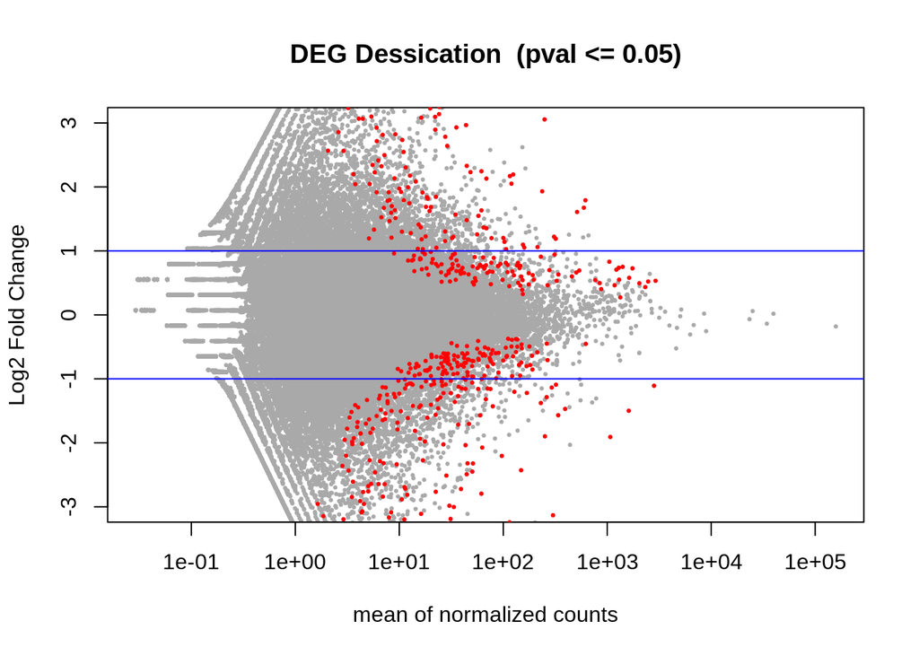

```r
tmp <- deseq2.res
plot(tmp$baseMean, tmp$log2FoldChange, pch=20, cex=0.45, ylim=c(-3, 3), log="x", col="darkgray",
     main="DEG Dessication  (pval <= 0.05)",
     xlab="mean of normalized counts",
     ylab="Log2 Fold Change")
# Getting the significant points and plotting them again so they're a different color
tmp.sig <- deseq2.res[!is.na(deseq2.res$padj) & deseq2.res$padj <= 0.05, ]
points(tmp.sig$baseMean, tmp.sig$log2FoldChange, pch=20, cex=0.45, col="red")
# 2 FC lines
abline(h=c(-1,1), col="blue")
```

```r
write.table(tmp.sig, "~/gitrepos/olivia-classwork/output/DEGlist.tab", row.names = T)
head(tmp.sig)
```

```
## log2 fold change (MLE): condition desicated vs control
## Wald test p-value: condition desicated vs control
## DataFrame with 6 rows and 6 columns
##                 baseMean log2FoldChange     lfcSE      stat      pvalue
##                <numeric>      <numeric> <numeric> <numeric>   <numeric>
## NM_001305290.1  145.9137       0.458032  0.116185   3.94225 8.07203e-05
## NM_001305310.1   59.8424      -1.570876  0.264433  -5.94053 2.84095e-09
## NM_001305333.1  595.7287       1.674822  0.156353  10.71181 8.95882e-27
## NM_001305339.1   20.3262      -1.096653  0.267054  -4.10648 4.01736e-05
## NM_001305362.1  319.6270       1.189819  0.211053   5.63754 1.72496e-08
## NM_001305373.1  213.6937       1.059645  0.306402   3.45835 5.43503e-04
##                       padj
##                  <numeric>
## NM_001305290.1 9.56401e-03
## NM_001305310.1 1.64630e-06
## NM_001305333.1 5.71071e-23
## NM_001305339.1 5.96520e-03
## NM_001305362.1 8.20566e-06
## NM_001305373.1 3.47145e-02
```